# Tarantino Movies: Motherfucking Violence

I am looking at the curse words in Quinten Tarentino’s movies. The dataset is from Fivethrityeight’s github page(https://github.com/fivethirtyeight/data). The data set includes four variables: movie, type, word, minutes. All are self explanitory except for “type.” Type deliniates between swear word or death. If type is “death,” the word variable is *NA.*

```r
str(tarantino)
```

[output not shown]

This is a lsit of all the swear words used in Tarantino Movies.

```r
unique(tarantino$word)
```

```
 [1] "dick"          "dicks"         "fucked"        "fucking"       "bullshit"
 [6] "fuck"          "shit"          "motherfucker"  "pussy"         "fucks"
[11] "hell"          "jap"           "bastard"       "goddamn"       "motherfuckers"
[16] "asshole"       "ass"           "assholes"      "n-word"        "asses"
[21] "bitch"         "fuckup"        "fucker"        "shitty"        "asshead"
[26] "damn"          NA              "damned"        "bitches"       "wetback"
[31] "faggot"        "cocksucker"    "gook"          "fuckers"       "gooks"
[36] "motherfucking" "dickless"      "chickenshit"   "slope"         "fuckhead"
[41] "merde"         "shithead"      "cunt"          "cunts"         "fuckface"
[46] "cockblockery"  "japs"          "jew (verb)"    "bastards"      "horeshit"
[51] "shitless"      "shitting"      "negro"         "squaw"         "slut"
[56] "goddamned"     "jackass"       "horseshit"     "shittiest"     "shitload"
[61] "dumbass"
```

Notice how “fuck,” “fucked,” “fucking,” etc.. are all considered different. Because of this I group the words. The groups are “Fucks,” “Shits,” “Racial Slur,” “Gay Slur,” “Female Slur,” “Male Genitalia,” and “PG-13.”

These groups should be self explanitory. I should note, I removed the *NAs* that coresponded to deaths.

Here’s a quick look at the data:

```r
head(curses,10)
```

| movie | Count | word | minutes_in | group |
| --- | --- | --- | --- | --- |
| Reservoir Dogs | word | dick | 0.40 | Male Genitalia |
| Reservoir Dogs | word | dicks | 0.43 | Male Genitalia |
| Reservoir Dogs | word | fucked | 0.55 | Fucks |
| Reservoir Dogs | word | fucking | 0.61 | Fucks |
| Reservoir Dogs | word | bullshit | 0.61 | Shits |
| Reservoir Dogs | word | fuck | 0.66 | Fucks |
| Reservoir Dogs | word | shit | 0.90 | Shits |
| Reservoir Dogs | word | fuck | 1.43 | Fucks |
| Reservoir Dogs | word | dicks | 1.56 | Male Genitalia |
| Reservoir Dogs | word | fuck | 1.66 | Fucks |

Now let’s see which Movies have the most curse words

```r
totalmovie
```

| movie | n | Percent |
| --- | --- | --- |
| Pulp Fiction | 469 | 27.5 |
| Reservoir Dogs | 421 | 24.7 |
| Jackie Brown | 368 | 21.6 |
| Django Unchained | 262 | 15.4 |
| Kill Bill: Vol. 2 | 69 | 4.0 |
| Inglorious Basterds | 58 | 3.4 |
| Kill Bill: Vol. 1 | 57 | 3.3 |

A quick view of which words are used:

```r
totalcurses
```

| Group | N | Percent |
| --- | --- | --- |
| Fucks | 772 | 45.3 |
| PG-13 | 384 | 22.5 |
| Shits | 253 | 14.8 |
| Racial Slur | 195 | 11.4 |
| Female Slur | 77 | 4.5 |
| Male Genitalia | 20 | 1.2 |
| Gay Slur | 3 | 0.2 |

Tarantino likes to have his actors say some form of the word “fuck.” Almost half of all curse words said in Taratino films are a varaint on the word fuck. Not a ton of “Gay Slurs.”

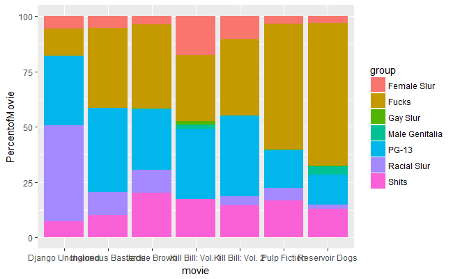

```r
DistributionChart
```

Also noticable is that the Kill Bill movies have a higher percentage of “Female Slurs.” this can be explained by the fact that the protagonist is female. So again this inconsistancy has an explanation.

Here is a cahrt that show’s tarantino’s movies sorted by the year they came out.

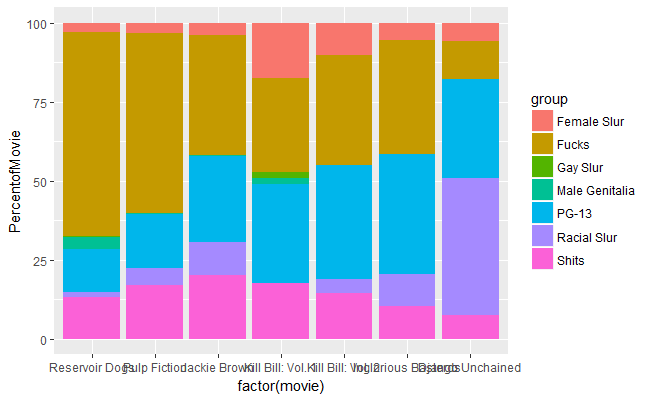

```r
moviesOverTime
```

Interestingly, over time it appears that tarantino is using fewer “Fucks” and “Shits.” While his use of “PG-13” words has increased over that time. This probably due to Tarantino’s increase in popularity. He is under pressure to produce movies that would appeal to a large population. Furthermore, overall cursing in his movies has also decreased.

```r
totalmovieyear
```

| movie | year | n | Percent |
| --- | --- | --- | --- |
| Reservoir Dogs | 1992 | 421 | 24.7 |
| Pulp Fiction | 1994 | 469 | 27.5 |
| Jackie Brown | 1997 | 368 | 21.6 |
| Kill Bill: Vol. 1 | 2003 | 57 | 3.3 |
| Kill Bill: Vol. 2 | 2004 | 69 | 4.0 |
| Inglorious Basterds | 2009 | 58 | 3.4 |
| Django Unchained | 2012 | 262 | 15.4 |

As you can see overall cursing has also decreased with the exception of Django Unchanged. This can be explained by the fact that good portion of the curse words are “Racial Slurs” and Django is a somewhat a period piece.